# KrishiHub Data Science Intern Assignment?? (spelling nahi aata edit it)

You are required to do analyze the dataset and find out the following insights :-

1. Top 10 keywords for funded projects and top 10 keywords for unfunded projects based on count.
2. Top 10 fastest funded projects.
3. Distribution of funded projects by country.
4. The goal amount range where the projects have been funded the highest. (Feel free to use your assumption for goal ranges)
5. How length and quality of project description correlates with project funding status.
6. Top 10 successful projects sorted by backer count and top 10 unsuccessful projects sorted by backer count.
7. How number of backers correlates with project success.
8. Successful and unsuccessful projects histogram (by count) per category (you will need to figure out the category of the project from the description, example - film, music, art etc.)

## 1.0 Loading the Dataset

```python
import numpy as np
import pandas as pd
```

```python
data = pd.read_csv('./data/kickstarter.csv')
```

```python
data.head()
```

|  | project_id | name | desc | goal | keywords | disable_communication | country | currency | deadline | state_changed_at | created_at | launched_at | backers_count | final_status |
| --- | --- | --- | --- | --- | --- | --- | --- | --- | --- | --- | --- | --- | --- | --- |
| 0 | kkst1451568084 | drawing for dollars | I like drawing pictures. and then i color them... | 20.0 | drawing-for-dollars | False | US | USD | 1241333999 | 1241334017 | 1240600507 | 1240602723 | 3 | 1 |
| 1 | kkst1474482071 | Sponsor Dereck Blackburn (Lostwars) Artist in ... | I, Dereck Blackburn will be taking upon an inc... | 300.0 | sponsor-dereck-blackburn-lostwars-artist-in-re... | False | US | USD | 1242429000 | 1242432018 | 1240960224 | 1240975592 | 2 | 0 |
| 2 | kkst183622197 | Mr. Squiggles | So I saw darkpony's successfully funded drawin... | 30.0 | mr-squiggles | False | US | USD | 1243027560 | 1243027818 | 1242163613 | 1242164398 | 0 | 0 |
| 3 | kkst597742710 | Help me write my second novel. | Do your part to help out starving artists and ... | 500.0 | help-me-write-my-second-novel | False | US | USD | 1243555740 | 1243556121 | 1240963795 | 1240966730 | 18 | 1 |
| 4 | kkst1913131122 | Support casting my sculpture in bronze | I'm nearing completion on a sculpture, current... | 2000.0 | support-casting-my-sculpture-in-bronze | False | US | USD | 1243769880 | 1243770317 | 1241177914 | 1241180541 | 1 | 0 |

## 2.0 Top 10 keywords for funded projects and top 10 keywords for unfunded projects

```python
# importing the needed stuffs
from collections import Counter
```

We'll create three Counter objects, one for keywords from funded projects, one for keywords from unfunded projects, and one for all the keywords.

```python
funded_counts = Counter()
unfunded_counts = Counter()
total_counts = Counter()
```

```python
data.keywords[0].split("-")
```

```
['drawing', 'for', 'dollars']
```

```python
# Loop over all the keywords in all the data.keywords and increment the counts in the appropriate counter objects
for i in range(len(data.keywords)):
    if(data.final_status[i] == 1):
        for kword in data.keywords[i].split("-"):
            funded_counts[kword] += 1
            total_counts[kword] += 1
    else:
        for kword in data.keywords[i].split("-"):
            unfunded_counts[kword] += 1
            total_counts[kword] += 1
```

Awesome now we have the Dicts mapped up, now we Need to examine the Dicts

```python
# Examining the Dicts for most common keywords in funded projects
funded_counts.most_common()
```

```python
# Examining the Dicts for most common keywords in unfunded projects
unfunded_counts.most_common()
```

We can tackle this problem with a 3rd grade math tool : "Ratios"

```python
def sigmoid(x):
        return 1 / (1 + np.exp(-x))

def fund2unfund_ratio(counts, f_counts,uf_counts, threshold):
    fund2unfund_ratios = Counter()

    # We can calculate the ratios of funded(a) to unfunded(b) uses of the most common keywords, as  (A / (B+1))
    # We need to consider a threshold for keywords to be "common" or uncommon, let's say if the keyword have been used more than 100 times it's uncommon
    for term,cnt in list(counts.most_common()):
        if(cnt > threshold):
            fund2unfund_r = (float(f_counts[term]) - float(uf_counts[term]))/ float(counts[term])
            fund2unfund_ratios[term] = sigmoid(fund2unfund_r) # we Return Sigmoid to avoid negetive numbers
    return fund2unfund_ratios
```

```python
# let's examine if the the thing works out or not
fund2unfund_ratios = fund2unfund_ratio(total_counts, funded_counts, unfunded_counts, 100)
print("Funded to Unfunded ratio for 'show' = {}".format(fund2unfund_ratios["show"]))
print("Funded to Unfunded ratio for 'me' = {}".format(fund2unfund_ratios["me"]))
print("Funded to Unfunded ratio for 'documentary' = {}".format(fund2unfund_ratios["documentary"]))
print("Funded to Unfunded ratio for 'vol' = {}".format(fund2unfund_ratios["vol"]))
```

```
Funded to Unfunded ratio for 'show' = 0.38493068747574627
Funded to Unfunded ratio for 'me' = 0.3935330158339715
Funded to Unfunded ratio for 'documentary' = 0.5600918883621294
Funded to Unfunded ratio for 'vol' = 0.503676404332629
```

```python
fund2unfund_ratios.most_common()
```

Looking closely at the values you just calculated, we see the following:

1. Keywords that we would see more often in funded projects – like "docunmentary" – have a ratios greater than 0.5.
2. Keywords that we would see more often in unfunded projects – like "show" – have ratios that are less than 0.5.
3. Other normal keywords, which don't really convey anything because one would expect to see them in all sorts of keyword mapping is scattered around 0.5

And the tool we are going to use now is "Set Theory"

```python
common_counts = Counter()

common_counts = funded_counts & unfunded_counts
common_counts.most_common()
```

```python
rfk = funded_counts - common_counts
rfk.most_common()
```

```python
rufk = unfunded_counts - common_counts
rf2f_ratios = fund2unfund_ratio(total_counts, rfk, rufk, 100)
```

```python
rf2f_ratios.most_common()
```

```python
reverse_rf2f_ratios = {l:k for k,l in sorted([(j,i) for i,j in rf2f_ratios.items()])}
```

```python
from itertools import islice

def top10unfunded(n, iterable):
    "Return first n items of the iterable as a list"
    return list(islice(iterable, n))
```

### 2.1 Top 10 keywords for funded projects

```python
for word, val in rf2f_ratios.most_common(10):
    print("{}".format(word) )
```

```
dice
wallet
pen
board
detroit
card
documentary
raspberry
deck
rpg
```

### 2.2 Top 10 keywords for unfunded projects

```python
for word, val in (top10unfunded(10,reverse_rf2f_ratios.items())):
    print("{}".format(word) )
```

```
network
app
website
bbq
social
restaurant
truck
clothing
organic
online
```

## 3.0 Top 10 fastest funded projects

```python
"""
cols = ['project_id', 'name', 'time_took']
ffp = pd.DataFrame(columns=cols)
for i in range(len(data)):
    if (data.final_status[i] == 1):
        time = float(data.state_changed_at[i]) - float(data.launched_at[i])
        ffp = ffp.append(pd.Series([data.project_id[i], data.name[i], time], index=cols),ignore_index=True)
ffp.to_csv('fastestfundedproject.csv', ind)
"""
```

[output not shown]

```python
ffp=pd.read_csv('fastestfundedproject.csv')
```

### 3.1 Top 10 Fastest Funded Project

```python
ffp10 = ffp.sort_values(by=['time_took']).head(10)
```

```python
ffp10
```

|  | project_id | name | time_took |
| --- | --- | --- | --- |
| 19993 | kkst140249903 | A £24 Poem | 112756.0 |
| 24233 | kkst434712061 | Fear and Football in Las Vegas | 115961.0 |
| 20970 | kkst979045536 | A £5 Poem | 117582.0 |
| 19047 | kkst1371254835 | Archive 2013: From the Mixed-Up Files of Diana... | 154809.0 |
| 11757 | kkst1386318425 | Airplanes above us, and their very first tour... | 161253.0 |
| 655 | kkst1903984239 | Skye's Epic Demo | 170176.0 |
| 29132 | kkst1571319043 | Rikki presents... K!ck$tart 3 | 172556.0 |
| 25753 | kkst573437181 | ≈≈≈ Bacon Dinner ≈≈≈ | 172800.0 |
| 4561 | kkst19084902 | popup | 172800.0 |
| 30721 | kkst124559477 | Save Our Kosmos! | 172802.0 |

## 4.0 Distribution of funded projects by country

```python
country_distrib = Counter()
```

```python
for i in range(len(data)):
    if (data.final_status[i]==1):
        country_distrib[data.country[i]] += 1
```

```python
countryD = dict(country_distrib)
country_distribution = pd.DataFrame(dict(country = list(countryD.keys()),
                                         project_count = list(countryD.values()))
                                   )
```

```python
country_distribution
```

|  | country | project_count |
| --- | --- | --- |
| 0 | US | 30573 |
| 1 | GB | 2510 |
| 2 | CA | 837 |
| 3 | AU | 343 |
| 4 | NZ | 80 |
| 5 | NL | 88 |
| 6 | SE | 45 |
| 7 | NO | 18 |
| 8 | DK | 44 |
| 9 | IE | 23 |

```python
import matplotlib.pyplot as plt
import seaborn as sns
sns.set()
```

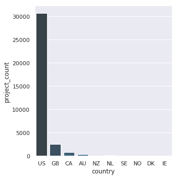

```python
a = sns.catplot(x="country", y="project_count",kind="bar",palette="Blues_d",data=country_distribution)
```

We see that most of the Projects are frm the US

## 5.0 The goal amount range where the projects have been funded the highest.

```python
funded = data[data['final_status']>0]
goalsorted = funded.sort_values(by=['goal'], ascending=False)
goaltop1per = goalsorted.head(int(len(goalsorted)*.01))
```

We are taking the top 1% of the funded projects with highest goals in decending order to find the goal range

```python
print("The Goal amount of highest funded project ranges from :{} - {} ".format(float(((goaltop1per.head(1))['goal'])),float(((goaltop1per.tail(1))['goal']))))
```

```
The Goal amount of highest funded project ranges from :2000000.0 - 100000.0
```

```python
# we can get the project length by simply computing the time between deadline and creation date
data['project_length'] = data.deadline - data.created_at
```

Getting the quality of a project's description can be done by many machine learning techniques but for now let's rate the description of the project via it's sentimental ratings

```python
from textblob import TextBlob
```

TextBlob is a Python library for processing textual data. It provides functions for common natural language processing (NLP) tasks such as part-of-speech tagging, noun phrase extraction, sentiment analysis, and more.

Here we shall judge the quality of Description of project by the subjectivity of the project description.

```python
quality = []
```

```python
for text in data.desc:
    blob = TextBlob(str(text))
    quality.append(blob.sentiment.subjectivity)
```

```python
len(quality)
```

```
108129
```

```python
data['desc_quality'] = quality
```

```python
data.head()
```

[output not shown]

```python
correlation= data.corr()
```

```python
correlation['project_length']['desc_quality']
```

```
0.013428418394046458
```

## 7.0 Top 10 successful projects sorted by backer count and top 10 unsuccessful projects sorted by backer count.

```python
unfunded = data[data['final_status'] == 0]
```

```python
backersortedfunded = funded.sort_values(by=['backers_count'], ascending=False)
backersortedunfunded = unfunded.sort_values(by=['backers_count'], ascending=False)
```

### 7.1 Top 10 successfull projects sorted by backer count(high-low)

```python
backersortedfunded.head(10)
```

|  | project_id | name | desc | goal | keywords | disable_communication | country | currency | deadline | state_changed_at | created_at | launched_at | backers_count | final_status |
| --- | --- | --- | --- | --- | --- | --- | --- | --- | --- | --- | --- | --- | --- | --- |
| 92361 | kkst581550534 | Exploding Kittens | This is a card game for people who are into ki... | 10000.0 | exploding-kittens | False | US | USD | 1424397600 | 1424397679 | 1418632794 | 1421776819 | 219382 | 1 |
| 62444 | kkst1352289371 | Bring Reading Rainbow Back for Every Child, Ev... | Bring Reading Rainbow’s library of interactive... | 1000000.0 | bring-reading-rainbow-back-for-every-child-eve... | False | US | USD | 1404327600 | 1404327611 | 1398222021 | 1401282345 | 105857 | 1 |
| 17099 | kkst118392388 | Double Fine Adventure | An adventure game from Tim Schafer, Double Fin... | 400000.0 | double-fine-adventure | False | US | USD | 1331683200 | 1331683219 | 1328144239 | 1328752372 | 87142 | 1 |
| 97967 | kkst1905637962 | Pebble Time - Awesome Smartwatch, No Compromises | Color e-paper smartwatch with up to 7 days of ... | 500000.0 | pebble-time-awesome-smartwatch-no-compromises | False | US | USD | 1427508000 | 1427508015 | 1423542328 | 1424789082 | 78471 | 1 |
| 36809 | kkst772487521 | Torment: Tides of Numenera | A story-driven CRPG set in the world of Monte ... | 900000.0 | torment-tides-of-numenera | False | US | USD | 1365206400 | 1365206432 | 1359134981 | 1362577657 | 74405 | 1 |
| 29154 | kkst1576551554 | Project Eternity | Project Eternity is an isometric, party-based ... | 1100000.0 | project-eternity | False | US | USD | 1350435600 | 1350435629 | 1344536374 | 1347642064 | 73986 | 1 |
| 20868 | kkst2103240519 | Pebble: E-Paper Watch for iPhone and Android | Pebble is a customizable watch. Download new w... | 100000.0 | pebble-e-paper-watch-for-iphone-and-android | False | US | USD | 1337396400 | 1337396419 | 1332451302 | 1334120344 | 68929 | 1 |
| 46541 | kkst105228151 | Mighty No. 9 | Classic Japanese side-scrolling action, evolve... | 900000.0 | mighty-no-9 | False | US | USD | 1380673141 | 1380673141 | 1376517708 | 1377994741 | 67226 | 1 |
| 25664 | kkst609499573 | OUYA: A New Kind of Video Game Console | Cracking open the last closed platform: the TV... | 950000.0 | ouya-a-new-kind-of-video-game-console | False | US | USD | 1344488400 | 1344491772 | 1337044803 | 1341924281 | 63416 | 1 |
| 70791 | kkst1586234393 | COOLEST COOLER: 21st Century Cooler that's Act... | The COOLEST is a portable party disguised as a... | 50000.0 | coolest-cooler-21st-century-cooler-thats-actually | False | US | USD | 1409360400 | 1409360410 | 1382478674 | 1404807277 | 62642 | 1 |

### 7.1 Top 10 unsuccessfull projects sorted by backer count(high-low)

```python
backersortedunfunded.head(10)
```

|  | project_id | name | desc | goal | keywords | disable_communication | country | currency | deadline | state_changed_at | created_at | launched_at | backers_count | final_status | project_length |
| --- | --- | --- | --- | --- | --- | --- | --- | --- | --- | --- | --- | --- | --- | --- | --- |
| 81147 | kkst47587774 | anonabox : a Tor hardware router (Suspended) | The anonabox is an open source embedded networ... | 7500.0 | anonabox-a-tor-hardware-router | True | US | USD | 1415755186 | 1413567021 | 1408581552 | 1413159586 | 8928 | 0 | 7173634 |
| 100410 | kkst535795688 | Descent: Underground | Descent is back! Pilot your ship & battle foes... | 600000.0 | descent-underground | False | US | USD | 1428710400 | 1428710419 | 1422892173 | 1426005725 | 8164 | 0 | 5818227 |
| 35213 | kkst958457175 | PROJECT AWAKENED | Craft the videogame character of your dreams. ... | 500000.0 | project-awakened | False | US | USD | 1362584400 | 1362584400 | 1357792081 | 1359992400 | 6287 | 0 | 4792319 |
| 30719 | kkst1354390191 | Hero-U: Rogue to Redemption by the Quest for G... | Hero-U is a turn-based PC RPG with adventure g... | 400000.0 | hero-u-rogue-to-redemption | False | US | USD | 1353443400 | 1353443432 | 1348299872 | 1350675073 | 6093 | 0 | 5143528 |
| 80667 | kkst15305518 | THE BLACK GLOVE | An eerie, surrealistic, first-person game expe... | 550000.0 | the-black-glove | False | US | USD | 1415395800 | 1415395813 | 1404827063 | 1412627444 | 5961 | 0 | 10568737 |
| 58005 | kkst1245108404 | Outcast Reboot HD | Taking one of the most engrossing open-world a... | 600000.0 | outcast-reboot-hd | False | US | USD | 1399499940 | 1399499964 | 1394102692 | 1396883151 | 5194 | 0 | 5397248 |
| 91135 | kkst1189968885 | Freaker Feet! 127 USA made sock designs! | Let's reclaim the import-dominated sock indust... | 250000.0 | freaker-feet-127-usa-made-sock-designs | False | US | USD | 1423580408 | 1423580416 | 1418789218 | 1420124408 | 4948 | 0 | 4791190 |
| 42881 | kkst1944462042 | LFG - The Fork of Truth | A 4-player co-op RPG based on the online comic... | 600000.0 | lfg-the-fork-of-truth | False | US | USD | 1374287116 | 1374287120 | 1370023672 | 1371695116 | 4201 | 0 | 4263444 |
| 29231 | kkst1550037820 | Blackspace - Plan. Dig. Defend. Survive. | A unique action RTS with an emphasis on defens... | 350000.0 | blackspace-plan-dig-defend-survive | False | US | USD | 1350577840 | 1350577840 | 1346202549 | 1347985840 | 4150 | 0 | 4375291 |
| 31690 | kkst1047539099 | SPORTSFRIENDS featuring Johann Sebastian Joust | A compendium of four joyfully fun local multip... | 150000.0 | sportsfriends-featuring-johann-sebastian-joust | False | US | USD | 1355173200 | 1355173231 | 1350707810 | 1352411734 | 4146 | 0 | 4465390 |

## 8.0 How number of backers correlates with project success.

```python
# We need to normalize backers count
average = data["backers_count"].mean()
SD = data["backers_count"].std()

data["norm_backers_count"] = sigmoid((data.backers_count -average)/SD)
```

```python
correlation= data.corr()
```

```python
correlation['final_status']['norm_backers_count']
```

```
0.34769990334760775
```

We see that final status of the project slightly positively correalates with the norm backers count.

### 9.0 Successful and unsuccessful projects histogram (by count) per category

```python
# Loop over all the keywords in all the data.keywords and increment the counts in the appropriate counter objects
from textblob import TextBlob
blob = TextBlob(data.keywords[6])
```

```python
data.keywords[6]
```

```
'igoozex-free-iphone-app'
```

```python
blob = blob.replace("-"," ")
```

```python
blob.noun_phrases
```

```
WordList(['free iphone app'])
```

```python
blob.sentiment
```

```
Sentiment(polarity=0.4, subjectivity=0.8)
```

```python
def get_category(txt):
    category_counte= Counter()

    a=[]
    blob = TextBlob(str(txt))
    blob = blob.replace("-"," ")
    for item in list(blob.noun_phrases):
        bob = TextBlob(item)
        category_counte[item] = sigmoid((float(bob.polarity))/((float(bob.subjectivity))+1))

    if (len(list(category_counte.most_common()))>0):
        a = list((category_counte.most_common())[0])
        return str(a[0])
    else:
        return "others"
```

```python
categ=[]
```

```python
for i in range(len(data.keywords)):
    categ.append(get_category(data["keywords"][i]))
```

```python
categ
```

```python
data["test"] = categ
```

```python
data.head(7)
```

|  | project_id | name | desc | goal | keywords | disable_communication | country | currency | deadline | state_changed_at | created_at | launched_at | backers_count | final_status | project_length | norm_backers_count | test |
| --- | --- | --- | --- | --- | --- | --- | --- | --- | --- | --- | --- | --- | --- | --- | --- | --- | --- |
| 0 | kkst1451568084 | drawing for dollars | I like drawing pictures. and then i color them... | 20.0 | drawing-for-dollars | False | US | USD | 1241333999 | 1241334017 | 1240600507 | 1240602723 | 3 | 1 | 733492 | 0.474419 | others |
| 1 | kkst1474482071 | Sponsor Dereck Blackburn (Lostwars) Artist in ... | I, Dereck Blackburn will be taking upon an inc... | 300.0 | sponsor-dereck-blackburn-lostwars-artist-in-re... | False | US | USD | 1242429000 | 1242432018 | 1240960224 | 1240975592 | 2 | 0 | 1468776 | 0.474207 | sponsor dereck blackburn lostwars artist |
| 2 | kkst183622197 | Mr. Squiggles | So I saw darkpony's successfully funded drawin... | 30.0 | mr-squiggles | False | US | USD | 1243027560 | 1243027818 | 1242163613 | 1242164398 | 0 | 0 | 863947 | 0.473783 | mr squiggles |
| 3 | kkst597742710 | Help me write my second novel. | Do your part to help out starving artists and ... | 500.0 | help-me-write-my-second-novel | False | US | USD | 1243555740 | 1243556121 | 1240963795 | 1240966730 | 18 | 1 | 2591945 | 0.477598 | others |
| 4 | kkst1913131122 | Support casting my sculpture in bronze | I'm nearing completion on a sculpture, current... | 2000.0 | support-casting-my-sculpture-in-bronze | False | US | USD | 1243769880 | 1243770317 | 1241177914 | 1241180541 | 1 | 0 | 2591966 | 0.473995 | others |
| 5 | kkst1085176748 | daily digest | I'm a fledgling videoblogger living in Brookly... | 700.0 | daily-digest | False | US | USD | 1243815600 | 1243816219 | 1241050799 | 1241464468 | 14 | 0 | 2764801 | 0.476750 | others |
| 6 | kkst1468954715 | iGoozex - Free iPhone app | I am an independent iPhone developer that beli... | 250.0 | igoozex-free-iphone-app | False | US | USD | 1243872000 | 1243872028 | 1241725172 | 1241736308 | 2 | 0 | 2146828 | 0.474207 | free iphone app |

```python
countercategorized = Counter()
```

```python
for sentances in categ:

    sentance = sentances.split(" ")
    for words in sentance:
        countercategorized[words] += 1
```

```python
top30categ=list(dict(countercategorized.most_common(30)))
```

```python
top30categ
```

```
['others',
 'new',
 'album',
 'project',
 'film',
 'debut',
 'music',
 'book',
 'art',
 'ep',
 'series',
 'short',
 'game',
 'cd',
 'video',
 'full',
 'tour',
 'length',
 'record',
 'magazine',
 'app',
 'show',
 'novel',
 'web',
 'life',
 'studio',
 'world',
 'documentary',
 'release',
 'food']
```

```python
category30list=[]
for sentances in categ:
    sentance = sentances.split(" ")
    for words in sentance:
        if (words in top30categ):
            category30list.append(words)
            break
        else:
            category30list.append('others')
            break
```

```python
data["category"] = category30list
```

```python
data.head()
```

|  | project_id | name | desc | goal | keywords | disable_communication | country | currency | deadline | state_changed_at | created_at | launched_at | backers_count | final_status | project_length | norm_backers_count | test | category |
| --- | --- | --- | --- | --- | --- | --- | --- | --- | --- | --- | --- | --- | --- | --- | --- | --- | --- | --- |
| 0 | kkst1451568084 | drawing for dollars | I like drawing pictures. and then i color them... | 20.0 | drawing-for-dollars | False | US | USD | 1241333999 | 1241334017 | 1240600507 | 1240602723 | 3 | 1 | 733492 | 0.474419 | others | others |
| 1 | kkst1474482071 | Sponsor Dereck Blackburn (Lostwars) Artist in ... | I, Dereck Blackburn will be taking upon an inc... | 300.0 | sponsor-dereck-blackburn-lostwars-artist-in-re... | False | US | USD | 1242429000 | 1242432018 | 1240960224 | 1240975592 | 2 | 0 | 1468776 | 0.474207 | sponsor dereck blackburn lostwars artist | others |
| 2 | kkst183622197 | Mr. Squiggles | So I saw darkpony's successfully funded drawin... | 30.0 | mr-squiggles | False | US | USD | 1243027560 | 1243027818 | 1242163613 | 1242164398 | 0 | 0 | 863947 | 0.473783 | mr squiggles | others |
| 3 | kkst597742710 | Help me write my second novel. | Do your part to help out starving artists and ... | 500.0 | help-me-write-my-second-novel | False | US | USD | 1243555740 | 1243556121 | 1240963795 | 1240966730 | 18 | 1 | 2591945 | 0.477598 | others | others |
| 4 | kkst1913131122 | Support casting my sculpture in bronze | I'm nearing completion on a sculpture, current... | 2000.0 | support-casting-my-sculpture-in-bronze | False | US | USD | 1243769880 | 1243770317 | 1241177914 | 1241180541 | 1 | 0 | 2591966 | 0.473995 | others | others |

```python
unfunded = data[data['final_status'] == 0]
funded = data[data['final_status'] == 1]
```

```python
funded_counter = Counter()
unfunded_counter = Counter()
```

```python
for word in funded.category:
    if (word != 'others'):
        funded_counter[word] += 1
for word in unfunded.category:
    if (word != 'others'):
        unfunded_counter[word] += 1
```

```python
categories = (list(funded_counter.keys()))
fundedcount = (list(funded_counter.values()))
unfundedcount = (list(unfunded_counter.values()))
```

```python
categorydatas ={}

categorydatas = { 'categories' : categories, 'funded_count' : fundedcount, 'unfunded_count' : unfundedcount}
categorydata = pd.DataFrame.from_dict(categorydatas)
```

```python
sns.set(font_scale=1.2)
```

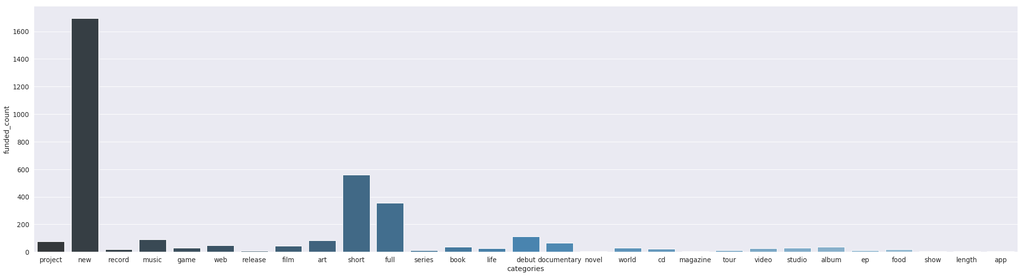

```python
histogrm= sns.catplot(x="categories", y="funded_count",kind="bar",palette="Blues_d",data=categorydata, height=8, aspect=29/8)
```

### 9.2 Unsuccessfull Project Count per category (almost)

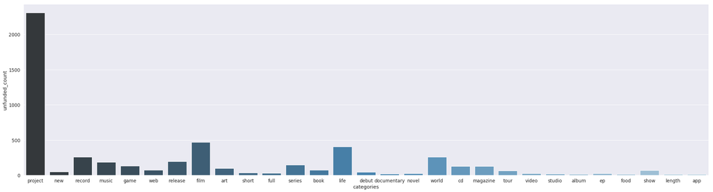

```python
histogrm= sns.catplot(x="categories", y="unfunded_count",kind="bar",palette="Blues_d",data=categorydata, height=8, aspect=29/8  )
```